# Assay Development Educational Series

Overview

January 12, 2016

# Motivation

- Reports of analytical validation in BRC submissions are often deficient
- Clinical researchers don’t give much attention to the biomarker assay and how well it needs to perform

### Goals

> Educate clinical researchers on importance of assessing and reporting on the performance of assays.

# Vision

- Write a series of short lessons that illustrate the key concepts
- Develop content agnostic to the delivery method (text-based and source figures)
  - In a structured and standardized format
  - Using diverse expertise across the program
- Deliver as a webpage as user-guided curriculum
  - Short courses
  - Tutorial Papers
  - Videos

# Lesson Structure

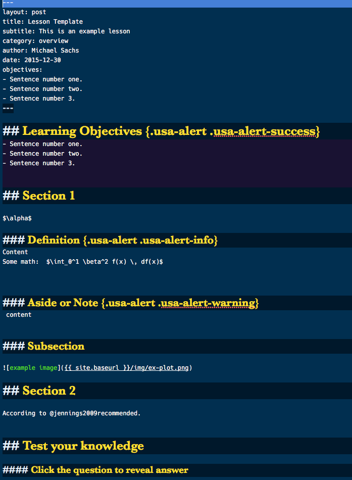

# Development Process

[interactive chart not shown]

# Draft Curriculum

# Terminology and Overview

1. Clinical Uses of Biomarkers (MC)
2. The Use of Biomarkers in Clinical Trials (LA)
3. Assay terminology (LH)

# Statistical Issues in Analytical Performance Assessment

1. Identifying and Describing Different Sources of Variation (MS)
2. Describing and comparing measures of location (MS)
3. Statistical issues in design and reporting analytical validation studies (LM)

# Statistical Issues in Biomarker-Based Clinical Trial Design

1. Enrichment Designs (LM)
2. Integrated Correlative Aims (MS)
3. Other (MS)

# Extra Topics

1. CLIA Certification and regulatory issues
2. SOP Development

# How to Contribute

- Write Lessons
  - Volunteers.
- Review Lessons
  - Volunteers?
- Development Website: https://sachsmc.github.io/assay-education
- Contact: michael.sachs@nih.gov